# *Tasca 7, Sprint 5:* *Log Transformation with Regular Expressions*

## Description

Records analysis is an important function for monitoring and alerting, compliance with security policies, auditing and regulatory compliance, responding to security incidents, and even forensic investigations. By analyzing log data, companies can more easily identify potential threats and other problems, find the root cause, and initiate a rapid response to mitigate risks.

### Level 1

The analyst must ensure that the records consist of a full range of messages and are interpreted according to the context. Registration elements should be standardized, using the same terms or terminology, to avoid confusion and provide cohesion.

As a Data Scientist you have been provided with access to the Logs where the activity of all visits to the travel agency's website "akumenius.com" is recorded.

### Exercise 1

Normalize, identify, and enumerate each of the attributes / variables in the "Web_access_log-akumenius.com" file structure that you will find in the "Data-sources" GitHub repository.

```python
# importing libraries
import pandas as pd
import numpy as np
import matplotlib as plt
import seaborn as sns
import matplotlib as mpl
import matplotlib.pyplot as plt
import matplotlib.patches as patches
import re

import warnings

warnings.filterwarnings('ignore')

pd.set_option('display.max_columns', None)
```

with open('../Data/Web_access_log-akumenius.com.txt') as weblog: mylist1 = list(weblog)

```python
weblog = pd.read_csv('../Data/Web_access_log-akumenius.com.txt',
                     sep='delimiter',
                     header=None,
                     engine='python',
                     index_col=False,
                     names=['Text'])
print(len(weblog))
weblog.head()
```

```
261873
```

|  | Text |
| --- | --- |
| 0 | localhost 127.0.0.1 - - [23/Feb/2014:03:10:31 ... |
| 1 | localhost 127.0.0.1 - - [23/Feb/2014:03:10:31 ... |
| 2 | localhost 127.0.0.1 - - [23/Feb/2014:03:10:31 ... |
| 3 | localhost 127.0.0.1 - - [23/Feb/2014:03:10:31 ... |
| 4 | localhost 127.0.0.1 - - [23/Feb/2014:03:10:31 ... |

```python
df_weblog = weblog.drop_duplicates()
print(len(df_weblog))
df_weblog.head()
```

```
257310
```

|  | Text |
| --- | --- |
| 0 | localhost 127.0.0.1 - - [23/Feb/2014:03:10:31 ... |
| 22 | www.akumenius.com 66.249.76.216 - - [23/Feb/20... |
| 23 | www.akumenius.com 66.249.76.216 - - [23/Feb/20... |
| 24 | www.akumenius.com 66.249.76.216 - - [23/Feb/20... |
| 25 | www.akumenius.com 66.249.76.216 - - [23/Feb/20... |

```python
df_weblog.tail(3)
```

|  | Text |
| --- | --- |
| 261868 | www.akumenius.com 5.255.253.53 - - [02/Mar/201... |
| 261869 | www.akumenius.com 74.86.158.107 - - [02/Mar/20... |
| 261870 | localhost 127.0.0.1 - - [02/Mar/2014:03:10:18 ... |

```python
df_weblog.describe()
```

|  | Text |
| --- | --- |
| count | 257310 |
| unique | 257310 |
| top | www.akumenius.com 65.55.55.229 - - [27/Feb/201... |
| freq | 1 |

```python
len(weblog)-len(df_weblog)
```

```
4563
```

```python
mylist = df_weblog.values.tolist()
len(mylist)
```

```
257310
```

```python
mylist[20]
```

```
['www.akumenius.com 157.55.35.112 - - [23/Feb/2014:03:11:02 +0100] "GET /destinos-baratos/destinos-caracteristicas/hoteles-baratos-en-Dubai_EMIRATOS%20ARABES%20UNIDOS-con-Actividades-de-animaci%C3%B3n HTTP/1.1" 200 14818 "-" "Mozilla/5.0 (compatible; bingbot/2.0; +http://www.bing.com/bingbot.htm)" V…
```

```python
mylist[93700]
```

```
['www.akumenius.com 66.249.76.216 - - [25/Feb/2014:09:19:06 +0100] "GET /destinos-caracteristicas/hoteles-baratos-en-Trier_ALEMANIA-con-Sauna HTTP/1.1" 200 7198 "-" "Mozilla/5.0 (compatible; Googlebot/2.1; +http://www.google.com/bot.html)" VLOG=-']
```

#### Separating attributes / variables

```python
def regexFinder(text, regex):
    result = re.search(regex, str(text[0]))
    if result != None:
        return result.group(0).strip()
    else:
        return ''
```

```python
mylist[200][0]
```

```
'www.akumenius.com 66.249.76.216 - - [23/Feb/2014:03:15:39 +0100] "GET /hoteles-baratos/ofertas-hotel-Husa-Patagonia-en-Arinsal-1702b-destinos.html HTTP/1.1" 404 3100 "-" "Mozilla/5.0 (compatible; Googlebot/2.1; +http://www.google.com/bot.html)" VLOG=-'
```

```python
agencyurl = '^(www.)*[A-Za-z]+\.[A-Za-z]+|localhost'
df_weblog['AgencyURL'] = [regexFinder(s, agencyurl) for s in mylist]
df_weblog.tail()
```

|  | Text | AgencyURL |
| --- | --- | --- |
| 261866 | www.akumenius.com 5.255.253.53 - - [02/Mar/201... | www.akumenius.com |
| 261867 | akumenius.es 5.255.253.53 - - [02/Mar/2014:03:... | akumenius.es |
| 261868 | www.akumenius.com 5.255.253.53 - - [02/Mar/201... | www.akumenius.com |
| 261869 | www.akumenius.com 74.86.158.107 - - [02/Mar/20... | www.akumenius.com |
| 261870 | localhost 127.0.0.1 - - [02/Mar/2014:03:10:18 ... | localhost |

```python
df_weblog.head()
```

|  | Text | AgencyURL |
| --- | --- | --- |
| 0 | localhost 127.0.0.1 - - [23/Feb/2014:03:10:31 ... | localhost |
| 22 | www.akumenius.com 66.249.76.216 - - [23/Feb/20... | www.akumenius.com |
| 23 | www.akumenius.com 66.249.76.216 - - [23/Feb/20... | www.akumenius.com |
| 24 | www.akumenius.com 66.249.76.216 - - [23/Feb/20... | www.akumenius.com |
| 25 | www.akumenius.com 66.249.76.216 - - [23/Feb/20... | www.akumenius.com |

```python
visitorurl = '(http|ftp|https)://([\w_-]+(?:(?:\.[\w_-]+)+))([\w.,@?^=%&:/~+#-]*[\w@?^=%&/~+#-])?'
df_weblog['VisitorURL'] = [regexFinder(s, visitorurl) for s in mylist]
df_weblog.head()
```

|  | Text | AgencyURL | VisitorURL |
| --- | --- | --- | --- |
| 0 | localhost 127.0.0.1 - - [23/Feb/2014:03:10:31 ... | localhost |  |
| 22 | www.akumenius.com 66.249.76.216 - - [23/Feb/20... | www.akumenius.com | http://www.google.com/bot.html |
| 23 | www.akumenius.com 66.249.76.216 - - [23/Feb/20... | www.akumenius.com | http://www.google.com/bot.html |
| 24 | www.akumenius.com 66.249.76.216 - - [23/Feb/20... | www.akumenius.com | http://www.google.com/bot.html |
| 25 | www.akumenius.com 66.249.76.216 - - [23/Feb/20... | www.akumenius.com | http://www.google.com/bot.html |

```python
date = '[0-9]{2}\/[A-Z][a-z]{2}\/[0-9]{4}'
df_weblog['Date'] = [regexFinder(s, date) for s in mylist]
df_weblog.head()
```

|  | Text | AgencyURL | VisitorURL | Date |
| --- | --- | --- | --- | --- |
| 0 | localhost 127.0.0.1 - - [23/Feb/2014:03:10:31 ... | localhost |  | 23/Feb/2014 |
| 22 | www.akumenius.com 66.249.76.216 - - [23/Feb/20... | www.akumenius.com | http://www.google.com/bot.html | 23/Feb/2014 |
| 23 | www.akumenius.com 66.249.76.216 - - [23/Feb/20... | www.akumenius.com | http://www.google.com/bot.html | 23/Feb/2014 |
| 24 | www.akumenius.com 66.249.76.216 - - [23/Feb/20... | www.akumenius.com | http://www.google.com/bot.html | 23/Feb/2014 |
| 25 | www.akumenius.com 66.249.76.216 - - [23/Feb/20... | www.akumenius.com | http://www.google.com/bot.html | 23/Feb/2014 |

```python
time = '\:[0-9]{2}\:[0-9]{2}\:[0-9]{2}'
df_weblog['Time'] = [regexFinder(s, time) for s in mylist]
df_weblog['Time'] = df_weblog['Time'].map(lambda x: x.lstrip(':'))
```

```python
request = 'GET|HEAD|PUT|POST|TRACE'
df_weblog['Request'] = [regexFinder(s, request) for s in mylist]
df_weblog.head()
```

|  | Text | AgencyURL | VisitorURL | Date | Time | Request |
| --- | --- | --- | --- | --- | --- | --- |
| 0 | localhost 127.0.0.1 - - [23/Feb/2014:03:10:31 ... | localhost |  | 23/Feb/2014 | 03:10:31 |  |
| 22 | www.akumenius.com 66.249.76.216 - - [23/Feb/20... | www.akumenius.com | http://www.google.com/bot.html | 23/Feb/2014 | 03:10:31 | GET |
| 23 | www.akumenius.com 66.249.76.216 - - [23/Feb/20... | www.akumenius.com | http://www.google.com/bot.html | 23/Feb/2014 | 03:10:33 | GET |
| 24 | www.akumenius.com 66.249.76.216 - - [23/Feb/20... | www.akumenius.com | http://www.google.com/bot.html | 23/Feb/2014 | 03:10:35 | GET |
| 25 | www.akumenius.com 66.249.76.216 - - [23/Feb/20... | www.akumenius.com | http://www.google.com/bot.html | 23/Feb/2014 | 03:10:38 | GET |

```python
search = '\s(\/[0-9A-Za-z-_%]{4}[0-9A-Za-z-_%]+)+'
df_weblog['SearchKey'] = [regexFinder(s, search) for s in mylist]
df_weblog.head()
```

|  | Text | AgencyURL | VisitorURL | Date | Time | Request | SearchKey |
| --- | --- | --- | --- | --- | --- | --- | --- |
| 0 | localhost 127.0.0.1 - - [23/Feb/2014:03:10:31 ... | localhost |  | 23/Feb/2014 | 03:10:31 |  |  |
| 22 | www.akumenius.com 66.249.76.216 - - [23/Feb/20... | www.akumenius.com | http://www.google.com/bot.html | 23/Feb/2014 | 03:10:31 | GET | /hoteles-baratos/ofertas-hotel-Club- |
| 23 | www.akumenius.com 66.249.76.216 - - [23/Feb/20... | www.akumenius.com | http://www.google.com/bot.html | 23/Feb/2014 | 03:10:33 | GET | /hoteles-baratos/ofertas-hotel-Metropolis-Hote... |
| 24 | www.akumenius.com 66.249.76.216 - - [23/Feb/20... | www.akumenius.com | http://www.google.com/bot.html | 23/Feb/2014 | 03:10:35 | GET | /hoteles-baratos/ofertas-hotel-Faena-Hotel-Bue... |
| 25 | www.akumenius.com 66.249.76.216 - - [23/Feb/20... | www.akumenius.com | http://www.google.com/bot.html | 23/Feb/2014 | 03:10:38 | GET | /hoteles-baratos/ofertas-hotel-Kensington-Town... |

```python
res = '\s[0-9]{3}\s'
df_weblog['ResponseCode'] = [regexFinder(s, res) for s in mylist]
df_weblog.head()
```

|  | Text | AgencyURL | VisitorURL | Date | Time | Request | SearchKey | ResponseCode |
| --- | --- | --- | --- | --- | --- | --- | --- | --- |
| 0 | localhost 127.0.0.1 - - [23/Feb/2014:03:10:31 ... | localhost |  | 23/Feb/2014 | 03:10:31 |  |  | 200 |
| 22 | www.akumenius.com 66.249.76.216 - - [23/Feb/20... | www.akumenius.com | http://www.google.com/bot.html | 23/Feb/2014 | 03:10:31 | GET | /hoteles-baratos/ofertas-hotel-Club- | 404 |
| 23 | www.akumenius.com 66.249.76.216 - - [23/Feb/20... | www.akumenius.com | http://www.google.com/bot.html | 23/Feb/2014 | 03:10:33 | GET | /hoteles-baratos/ofertas-hotel-Metropolis-Hote... | 404 |
| 24 | www.akumenius.com 66.249.76.216 - - [23/Feb/20... | www.akumenius.com | http://www.google.com/bot.html | 23/Feb/2014 | 03:10:35 | GET | /hoteles-baratos/ofertas-hotel-Faena-Hotel-Bue... | 404 |
| 25 | www.akumenius.com 66.249.76.216 - - [23/Feb/20... | www.akumenius.com | http://www.google.com/bot.html | 23/Feb/2014 | 03:10:38 | GET | /hoteles-baratos/ofertas-hotel-Kensington-Town... | 404 |

```python
ip = '(25[0-5]|2[0-4][0-9]|[01]?[0-9][0-9]?)\.(25[0-5]|2[0-4][0-9]|[01]?[0-9][0-9]?)\.(25[0-5]|2[0-4][0-9]|[01]?[0-9][0-9]?)\.(25[0-5]|2[0-4][0-9]|[01]?[0-9][0-9]?)'
df_weblog['IPaddress'] = [regexFinder(s, ip) for s in mylist]
df_weblog.head()
```

|  | Text | AgencyURL | VisitorURL | Date | Time | Request | SearchKey | ResponseCode | IPaddress |
| --- | --- | --- | --- | --- | --- | --- | --- | --- | --- |
| 0 | localhost 127.0.0.1 - - [23/Feb/2014:03:10:31 ... | localhost |  | 23/Feb/2014 | 03:10:31 |  |  | 200 | 127.0.0.1 |
| 22 | www.akumenius.com 66.249.76.216 - - [23/Feb/20... | www.akumenius.com | http://www.google.com/bot.html | 23/Feb/2014 | 03:10:31 | GET | /hoteles-baratos/ofertas-hotel-Club- | 404 | 66.249.76.216 |
| 23 | www.akumenius.com 66.249.76.216 - - [23/Feb/20... | www.akumenius.com | http://www.google.com/bot.html | 23/Feb/2014 | 03:10:33 | GET | /hoteles-baratos/ofertas-hotel-Metropolis-Hote... | 404 | 66.249.76.216 |
| 24 | www.akumenius.com 66.249.76.216 - - [23/Feb/20... | www.akumenius.com | http://www.google.com/bot.html | 23/Feb/2014 | 03:10:35 | GET | /hoteles-baratos/ofertas-hotel-Faena-Hotel-Bue... | 404 | 66.249.76.216 |
| 25 | www.akumenius.com 66.249.76.216 - - [23/Feb/20... | www.akumenius.com | http://www.google.com/bot.html | 23/Feb/2014 | 03:10:38 | GET | /hoteles-baratos/ofertas-hotel-Kensington-Town... | 404 | 66.249.76.216 |

## Level 2

### Exercises 2

Clean, preprocesse, structure and transform (dataframe) the data in the Web Access register.

#### Checking Unique values

```python
df_weblog.describe()
```

|  | Text | AgencyURL | VisitorURL | Date | Time | Request | SearchKey | ResponseCode | IPaddress |
| --- | --- | --- | --- | --- | --- | --- | --- | --- | --- |
| count | 257310 | 257310 | 257310 | 257310 | 257310 | 257310 | 257310 | 257310 | 257310 |
| unique | 257310 | 5 | 2541 | 8 | 66635 | 4 | 62559 | 12 | 2921 |
| top | www.akumenius.com 65.55.55.229 - - [27/Feb/201... | www.akumenius.com | http://www.google.com/bot.html | 25/Feb/2014 | 16:19:28 | GET | /libraries/jqueryui | 200 | 66.249.76.216 |
| freq | 1 | 228102 | 52042 | 54963 | 99 | 228776 | 25424 | 222076 | 46382 |

```python
df_weblog.AgencyURL.unique()
```

```
array(['localhost', 'www.akumenius.com', 'akumenius.com', 'akumenius.es',
       'test.akumenius'], dtype=object)
```

```python
df_weblog.Date.unique()
```

```
array(['23/Feb/2014', '24/Feb/2014', '25/Feb/2014', '26/Feb/2014',
       '27/Feb/2014', '28/Feb/2014', '01/Mar/2014', '02/Mar/2014'],
      dtype=object)
```

```python
df_weblog.Request.unique()
```

```
array(['', 'GET', 'HEAD', 'POST'], dtype=object)
```

```python
df_weblog.ResponseCode.unique()
```

```
array(['200', '404', '304', '502', '301', '403', '408', '400', '206',
       '401', '302', '500'], dtype=object)
```

```python
df_weblog.tail(3)
```

|  | Text | AgencyURL | VisitorURL | Date | Time | Request | SearchKey | ResponseCode | IPaddress |
| --- | --- | --- | --- | --- | --- | --- | --- | --- | --- |
| 261868 | www.akumenius.com 5.255.253.53 - - [02/Mar/201... | www.akumenius.com | http://yandex.com/bots | 02/Mar/2014 | 03:05:39 | GET |  | 200 | 5.255.253.53 |
| 261869 | www.akumenius.com 74.86.158.107 - - [02/Mar/20... | www.akumenius.com | http://www.uptimerobot.com/ | 02/Mar/2014 | 03:09:52 | HEAD |  | 200 | 74.86.158.107 |
| 261870 | localhost 127.0.0.1 - - [02/Mar/2014:03:10:18 ... | localhost |  | 02/Mar/2014 | 03:10:18 |  |  | 200 | 127.0.0.1 |

#### Checking Null values

```python
df_weblog.isnull().values.any()
```

```
False
```

```python
df_weblog.isnull().sum().sum()
```

```
0
```

#### Extracting Browser and OS

```python
mylist[69288][0]
```

```
'www.akumenius.com 62.174.80.74 - - [24/Feb/2014:14:07:54 +0100] "GET /escapadas/escapada-calpe-magica-spa-hotel-ar-roca-esmeralda-spa-5c74558c32b496e3c91e9c18dd6279b9.html HTTP/1.1" 200 5637 "http://www.akumenius.com/chollos" "Mozilla/4.0 (compatible; MSIE 8.0; Windows NT 5.1; Trident/4.0; .NET CLR…
```

```python
from werkzeug.test import create_environ
from werkzeug.wrappers import Request

def bowser_on_mario(text):
    environ = create_environ()
    environ.update(HTTP_USER_AGENT=(text[0]))
    request = Request(environ)
    bowser = request.user_agent.browser
    mario = request.user_agent.platform
    return bowser, mario
```

```python
b, m = bowser_on_mario(mylist[6285])
print(b)
print(m)
```

```
google
None
```

```
- Many of the extracted browsers are 'google', which seems not true or suspicious at least.
- A detailed look in the matter reveals that they are most likely the googlebots.
- This is also confirmed by using another parser api to collect the browser and OS from the user agent information available in the dataset.
- For this reason, I will replace the 'google' with 'googlebots', to make it clear that those are most likely the 'bot' entries.
```

```python
from user_agents import parse
#ua_string = 'Mozilla/5.0 (Macintosh; U; Intel Mac OS X 10_6_3; en-us; Silk/1.1.0-80) AppleWebKit/533.16 (KHTML, like Gecko) Version/5.0 Safari/533.16 Silk-Accelerated=true'
ua_string = mylist[6285][0]
user_agent = parse(ua_string)
user_agent.is_mobile # returns False
user_agent.is_tablet # returns True
user_agent.is_touch_capable # returns True
user_agent.is_pc # returns False
user_agent.is_bot # returns False
str(user_agent) # returns "Kindle / Android / Amazon Silk 1.1.0-80"
```

```
'Spider / Other / Googlebot 2.1'
```

```python
d = []
for ind in range(len(mylist)):
    text = mylist[ind]
    b, m = bowser_on_mario(text)
    d.append({
        'Browser': b,
        'Platform': m,
    })

dd = pd.DataFrame(d)
dd.head()
```

|  | Browser | Platform |
| --- | --- | --- |
| 0 | None | None |
| 1 | google | None |
| 2 | google | None |
| 3 | google | None |
| 4 | google | None |

```python
dd.Browser.replace({"google": "Googlebot"}, inplace=True)
dd.head()
```

|  | Browser | Platform |
| --- | --- | --- |
| 0 | None | None |
| 1 | Googlebot | None |
| 2 | Googlebot | None |
| 3 | Googlebot | None |
| 4 | Googlebot | None |

```python
dd.describe()
```

|  | Browser | Platform |
| --- | --- | --- |
| count | 239186 | 168482 |
| unique | 18 | 11 |
| top | Googlebot | windows |
| freq | 52130 | 89708 |

```python
df_weblog['Browser'] = dd.Browser
df_weblog['Platform'] = dd.Platform
df_weblog.head(3)
```

|  | Text | AgencyURL | VisitorURL | Date | Time | Request | SearchKey | ResponseCode | IPaddress | Browser | Platform |
| --- | --- | --- | --- | --- | --- | --- | --- | --- | --- | --- | --- |
| 0 | localhost 127.0.0.1 - - [23/Feb/2014:03:10:31 ... | localhost |  | 23/Feb/2014 | 03:10:31 |  |  | 200 | 127.0.0.1 | None | None |
| 22 | www.akumenius.com 66.249.76.216 - - [23/Feb/20... | www.akumenius.com | http://www.google.com/bot.html | 23/Feb/2014 | 03:10:31 | GET | /hoteles-baratos/ofertas-hotel-Club- | 404 | 66.249.76.216 | Googlebot | None |
| 23 | www.akumenius.com 66.249.76.216 - - [23/Feb/20... | www.akumenius.com | http://www.google.com/bot.html | 23/Feb/2014 | 03:10:33 | GET | /hoteles-baratos/ofertas-hotel-Metropolis-Hote... | 404 | 66.249.76.216 | firefox | linux |

### Exercises 3

Geolocates IP's. Here is a page of interest: IP2Locattion: https://blog.ip2location.com/knowledge-base/how-to-add-a-sub-account-in-ip2location/

#### IP locations

```python
from geolite2 import geolite2

def get_country(ip):
    try:
        x = geo.get(ip)
    except ValueError:
        return ''
    try:
        return x['country']['names']['en'] if x else pd.np.nan
    except KeyError:
        return ''

geo = geolite2.reader()

unique_ips = df_weblog['IPaddress'].unique()
unique_ips = pd.Series(unique_ips, index = unique_ips)
df_weblog['country'] = df_weblog['IPaddress'].map(unique_ips.apply(get_country))

geolite2.close()
```

```python
len(unique_ips)
```

```
2921
```

```python
df_weblog.tail()
```

|  | Text | AgencyURL | VisitorURL | Date | Time | Request | SearchKey | ResponseCode | IPaddress | Browser | Platform | country |
| --- | --- | --- | --- | --- | --- | --- | --- | --- | --- | --- | --- | --- |
| 261866 | www.akumenius.com 5.255.253.53 - - [02/Mar/201... | www.akumenius.com | http://yandex.com/bots | 02/Mar/2014 | 03:05:34 | GET |  | 200 | 5.255.253.53 | NaN | NaN | Russia |
| 261867 | akumenius.es 5.255.253.53 - - [02/Mar/2014:03:... | akumenius.es | http://yandex.com/bots | 02/Mar/2014 | 03:05:35 | GET |  | 301 | 5.255.253.53 | NaN | NaN | Russia |
| 261868 | www.akumenius.com 5.255.253.53 - - [02/Mar/201... | www.akumenius.com | http://yandex.com/bots | 02/Mar/2014 | 03:05:39 | GET |  | 200 | 5.255.253.53 | NaN | NaN | Russia |
| 261869 | www.akumenius.com 74.86.158.107 - - [02/Mar/20... | www.akumenius.com | http://www.uptimerobot.com/ | 02/Mar/2014 | 03:09:52 | HEAD |  | 200 | 74.86.158.107 | NaN | NaN | United States |
| 261870 | localhost 127.0.0.1 - - [02/Mar/2014:03:10:18 ... | localhost |  | 02/Mar/2014 | 03:10:18 |  |  | 200 | 127.0.0.1 | NaN | NaN | NaN |

```python
df_weblog.head()
```

|  | Text | AgencyURL | VisitorURL | Date | Time | Request | SearchKey | ResponseCode | IPaddress | Browser | Platform | country |
| --- | --- | --- | --- | --- | --- | --- | --- | --- | --- | --- | --- | --- |
| 0 | localhost 127.0.0.1 - - [23/Feb/2014:03:10:31 ... | localhost |  | 23/Feb/2014 | 03:10:31 |  |  | 200 | 127.0.0.1 | None | None | NaN |
| 22 | www.akumenius.com 66.249.76.216 - - [23/Feb/20... | www.akumenius.com | http://www.google.com/bot.html | 23/Feb/2014 | 03:10:31 | GET | /hoteles-baratos/ofertas-hotel-Club- | 404 | 66.249.76.216 | Googlebot | None | United States |
| 23 | www.akumenius.com 66.249.76.216 - - [23/Feb/20... | www.akumenius.com | http://www.google.com/bot.html | 23/Feb/2014 | 03:10:33 | GET | /hoteles-baratos/ofertas-hotel-Metropolis-Hote... | 404 | 66.249.76.216 | firefox | linux | United States |
| 24 | www.akumenius.com 66.249.76.216 - - [23/Feb/20... | www.akumenius.com | http://www.google.com/bot.html | 23/Feb/2014 | 03:10:35 | GET | /hoteles-baratos/ofertas-hotel-Faena-Hotel-Bue... | 404 | 66.249.76.216 | Googlebot | None | United States |
| 25 | www.akumenius.com 66.249.76.216 - - [23/Feb/20... | www.akumenius.com | http://www.google.com/bot.html | 23/Feb/2014 | 03:10:38 | GET | /hoteles-baratos/ofertas-hotel-Kensington-Town... | 404 | 66.249.76.216 | Googlebot | None | United States |

```python
df_new = df_weblog.drop('Text', axis=1)
df_new.head()
```

|  | AgencyURL | VisitorURL | Date | Time | Request | SearchKey | ResponseCode | IPaddress | Browser | Platform | country |
| --- | --- | --- | --- | --- | --- | --- | --- | --- | --- | --- | --- |
| 0 | localhost |  | 23/Feb/2014 | 03:10:31 |  |  | 200 | 127.0.0.1 | None | None | NaN |
| 22 | www.akumenius.com | http://www.google.com/bot.html | 23/Feb/2014 | 03:10:31 | GET | /hoteles-baratos/ofertas-hotel-Club- | 404 | 66.249.76.216 | Googlebot | None | United States |
| 23 | www.akumenius.com | http://www.google.com/bot.html | 23/Feb/2014 | 03:10:33 | GET | /hoteles-baratos/ofertas-hotel-Metropolis-Hote... | 404 | 66.249.76.216 | firefox | linux | United States |
| 24 | www.akumenius.com | http://www.google.com/bot.html | 23/Feb/2014 | 03:10:35 | GET | /hoteles-baratos/ofertas-hotel-Faena-Hotel-Bue... | 404 | 66.249.76.216 | Googlebot | None | United States |
| 25 | www.akumenius.com | http://www.google.com/bot.html | 23/Feb/2014 | 03:10:38 | GET | /hoteles-baratos/ofertas-hotel-Kensington-Town... | 404 | 66.249.76.216 | Googlebot | None | United States |

```python
df_new['Date'] = pd.to_datetime(df_new.Date).dt.date
df_new = df_new.sort_values(by='Date', axis=0, ascending=True)
print(df_new.Date[0])
df_new.head()
```

```
2014-02-23
```

|  | AgencyURL | VisitorURL | Date | Time | Request | SearchKey | ResponseCode | IPaddress | Browser | Platform | country |
| --- | --- | --- | --- | --- | --- | --- | --- | --- | --- | --- | --- |
| 0 | localhost |  | 2014-02-23 | 03:10:31 |  |  | 200 | 127.0.0.1 | None | None | NaN |
| 26999 | www.akumenius.com | http://www.akumenius.com/hotel-list | 2014-02-23 | 18:26:06 | GET | /modules/raton/views/themes/bcoos/images/boto_... | 200 | 95.61.19.60 | Googlebot | None | Spain |
| 27000 | www.akumenius.com | http://www.akumenius.com/hotel-list | 2014-02-23 | 18:26:06 | GET | /modules/raton/views/themes/bcoos/images/boto_... | 200 | 95.61.19.60 | Googlebot | iphone | Spain |
| 27001 | www.akumenius.com | http://www.akumenius.com/hotel-list | 2014-02-23 | 18:26:06 | GET |  | 200 | 95.61.19.60 | Googlebot | None | Spain |
| 27002 | www.akumenius.com | http://www.akumenius.com/hotel-list | 2014-02-23 | 18:26:06 | GET | /modules/raton/views/themes/bcoos/images/logo_... | 200 | 95.61.19.60 | safari | ipad | Spain |

```python
# Saving this file to csv.

df_new.to_csv('../Data/weblog_cleaned.csv')
```

## Level 3

### Exercise 4*

Show me your creativity, Surprise me go one step further with the above analysis.

```python
df_new = pd.read_table('../Data/weblog_cleaned.csv', sep = ',', index_col=0)

df_new.head()
```

|  | AgencyURL | VisitorURL | Date | Time | Request | SearchKey | ResponseCode | IPaddress | Browser | Platform | country |
| --- | --- | --- | --- | --- | --- | --- | --- | --- | --- | --- | --- |
| 0 | localhost | NaN | 2014-02-23 | 03:10:31 | NaN | NaN | 200 | 127.0.0.1 | NaN | NaN | NaN |
| 26999 | www.akumenius.com | http://www.akumenius.com/hotel-list | 2014-02-23 | 18:26:06 | GET | /modules/raton/views/themes/bcoos/images/boto_... | 200 | 95.61.19.60 | Googlebot | NaN | Spain |
| 27000 | www.akumenius.com | http://www.akumenius.com/hotel-list | 2014-02-23 | 18:26:06 | GET | /modules/raton/views/themes/bcoos/images/boto_... | 200 | 95.61.19.60 | Googlebot | iphone | Spain |
| 27001 | www.akumenius.com | http://www.akumenius.com/hotel-list | 2014-02-23 | 18:26:06 | GET | NaN | 200 | 95.61.19.60 | Googlebot | NaN | Spain |
| 27002 | www.akumenius.com | http://www.akumenius.com/hotel-list | 2014-02-23 | 18:26:06 | GET | /modules/raton/views/themes/bcoos/images/logo_... | 200 | 95.61.19.60 | safari | ipad | Spain |

```python
df_new.isnull().values.any()
```

```
True
```

```python
df_new.isnull().sum().sum()
```

```
190443
```

```python
summary = df_new.groupby(['Date', 'AgencyURL']).count()
summary
```

| Date | AgencyURL | VisitorURL | Time | Request | SearchKey | ResponseCode | IPaddress | Browser | Platform | country |
| --- | --- | --- | --- | --- | --- | --- | --- | --- | --- | --- |
| 2014-02-23 | akumenius.com | 45 | 63 | 63 | 30 | 63 | 63 | 61 | 13 | 63 |
|  | akumenius.es | 6 | 17 | 17 | 5 | 17 | 17 | 17 | 1 | 17 |
|  | localhost | 0 | 956 | 4 | 3 | 956 | 956 | 889 | 373 | 7 |
|  | test.akumenius | 3 | 3 | 3 | 3 | 3 | 3 | 3 | 1 | 3 |
|  | www.akumenius.com | 38597 | 39196 | 39196 | 38382 | 39196 | 39196 | 38018 | 12989 | 39041 |
| 2014-02-24 | akumenius.com | 52 | 74 | 74 | 32 | 74 | 74 | 66 | 46 | 74 |
|  | akumenius.es | 4 | 18 | 18 | 2 | 18 | 18 | 18 | 7 | 18 |
|  | localhost | 0 | 3008 | 17 | 12 | 3008 | 3008 | 2756 | 2196 | 27 |
|  | test.akumenius | 2056 | 2203 | 2203 | 2199 | 2203 | 2203 | 2078 | 1921 | 2203 |
|  | www.akumenius.com | 40776 | 42105 | 42105 | 40471 | 42105 | 42105 | 38814 | 28168 | 41830 |
| 2014-02-25 | akumenius.com | 35 | 92 | 92 | 30 | 92 | 92 | 85 | 57 | 92 |
|  | akumenius.es | 4 | 8 | 8 | 2 | 8 | 8 | 6 | 4 | 8 |
|  | localhost | 3 | 3564 | 16 | 9 | 3564 | 3564 | 3308 | 2373 | 21 |
|  | test.akumenius | 50 | 52 | 52 | 52 | 52 | 52 | 51 | 39 | 52 |
|  | www.akumenius.com | 49982 | 51247 | 51247 | 48585 | 51247 | 51247 | 47484 | 33101 | 50973 |
| 2014-02-26 | akumenius.com | 53 | 117 | 117 | 44 | 117 | 117 | 110 | 84 | 117 |
|  | akumenius.es | 5 | 7 | 7 | 3 | 7 | 7 | 7 | 7 | 7 |
|  | localhost | 0 | 2243 | 55 | 33 | 2243 | 2243 | 2035 | 1670 | 58 |
|  | test.akumenius | 542 | 605 | 605 | 605 | 605 | 605 | 568 | 487 | 605 |
|  | www.akumenius.com | 31142 | 32671 | 32671 | 31143 | 32671 | 32671 | 30266 | 23497 | 32537 |
| 2014-02-27 | akumenius.com | 34 | 90 | 90 | 27 | 90 | 90 | 84 | 75 | 89 |
|  | akumenius.es | 10 | 15 | 15 | 5 | 15 | 15 | 13 | 10 | 15 |
|  | localhost | 3 | 1807 | 14 | 10 | 1807 | 1807 | 1667 | 1510 | 22 |
|  | test.akumenius | 11164 | 11273 | 11273 | 11269 | 11273 | 11273 | 10812 | 10165 | 11273 |
|  | www.akumenius.com | 26628 | 27720 | 27720 | 26268 | 27720 | 27720 | 25628 | 22549 | 27600 |
| 2014-02-28 | akumenius.com | 42 | 225 | 225 | 146 | 225 | 225 | 206 | 147 | 225 |
|  | akumenius.es | 8 | 13 | 13 | 6 | 13 | 13 | 7 | 5 | 13 |
|  | localhost | 2 | 1508 | 32 | 21 | 1508 | 1508 | 1314 | 1031 | 32 |
|  | test.akumenius | 14 | 14 | 14 | 14 | 14 | 14 | 12 | 11 | 14 |
|  | www.akumenius.com | 16559 | 17482 | 17482 | 16417 | 17482 | 17482 | 15134 | 11686 | 17340 |
| 2014-03-01 | akumenius.com | 41 | 70 | 70 | 22 | 70 | 70 | 57 | 47 | 70 |
|  | akumenius.es | 11 | 14 | 14 | 6 | 14 | 14 | 13 | 13 | 14 |
|  | localhost | 5 | 928 | 40 | 29 | 928 | 928 | 685 | 573 | 43 |
|  | test.akumenius | 134 | 137 | 137 | 137 | 137 | 137 | 25 | 21 | 137 |
|  | www.akumenius.com | 15745 | 16405 | 16405 | 15403 | 16405 | 16405 | 12683 | 10318 | 16306 |
| 2014-03-02 | akumenius.com | 8 | 10 | 10 | 2 | 10 | 10 | 0 | 0 | 10 |
|  | akumenius.es | 2 | 2 | 2 | 1 | 2 | 2 | 0 | 0 | 2 |
|  | localhost | 0 | 70 | 6 | 5 | 70 | 70 | 0 | 0 | 6 |
|  | test.akumenius | 2 | 2 | 2 | 2 | 2 | 2 | 0 | 0 | 2 |
|  | www.akumenius.com | 1219 | 1276 | 1276 | 1169 | 1276 | 1276 | 0 | 0 | 1276 |

```python
colors = 'teal'
titlesize = 16
xynamesize = 16
ticksize = 14
```

### Visitors distribution

#### Total visitors - Boxplot

```python
vis_date = (df_new[["Date", "VisitorURL"]].groupby(["Date"], as_index=False).count())
vis_date = vis_date.rename({"VisitorURL": "total_visitors"}, axis=1)
vis_date = vis_date.sort_values(by='total_visitors', ascending=False)
vis_date.head()
```

|  | Date | total_visitors |
| --- | --- | --- |
| 2 | 2014-02-25 | 50074 |
| 1 | 2014-02-24 | 42888 |
| 0 | 2014-02-23 | 38651 |
| 4 | 2014-02-27 | 37839 |
| 3 | 2014-02-26 | 31742 |

```
Text(0.5,1,'Number of visitor by date')
```

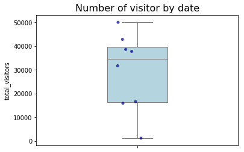

```python
ax = sns.boxplot(y=vis_date.total_visitors,
                 color='lightblue',
                 fliersize=5,
                 orient='v',
                 linewidth=1,
                 width=0.3)
ax = sns.stripplot(y=vis_date.total_visitors,
                   orient='v',
                   color='darkblue',
                   alpha=0.7)
ax.set_title('Number of visitor by date', fontsize=titlesize)
plt.show()
```

#### Visitors by date

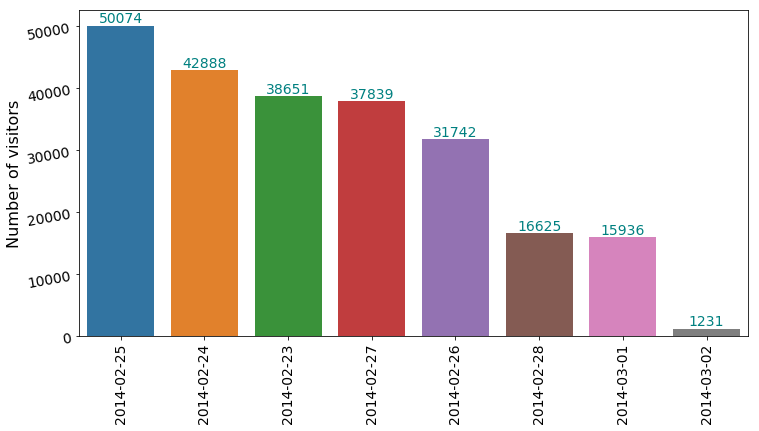

```python
fig = plt.figure(figsize=(12, 6))
plot_ = sns.barplot(y='total_visitors', x='Date', data=vis_date, orient='v')

plt.tick_params(axis='x', rotation=90, labelsize=ticksize)
plt.tick_params(axis='y', rotation=10, labelsize=ticksize)
plt.xlabel('', fontsize=xynamesize)
plt.ylabel('Number of visitors', fontsize=xynamesize)
for index, data in enumerate(vis_date.total_visitors):
    plt.text(x=index,
             y=data + 500,
             s=f"{data}",
             color=colors,
             fontdict=dict(fontsize=ticksize),
             ha='center')
plt.show()
```

#### Visitors by AgencyURL

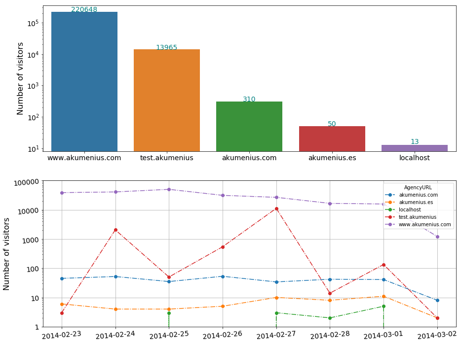

```python
f, ax = plt.subplots(2, 1, figsize=(15, 12))

df = (df_new[["AgencyURL", "VisitorURL"]].groupby(["AgencyURL"], as_index=False).count())
df = df.rename({"VisitorURL": "total_visitors"}, axis=1)
df = df.sort_values(by='total_visitors', ascending=False)

sns.barplot(y='total_visitors', x='AgencyURL', data=df, orient='v', ax=ax[0])
ax[0].set_ylabel('')
for index, data in enumerate(df.total_visitors):
    ax[0].text(x=index,
             y=data + 1,
             s=f"{data}",
             color=colors,
             fontdict=dict(fontsize=ticksize),
             ha='center')
ax[0].tick_params(axis='both', labelsize=ticksize)
ax[0].set_yscale('log')
ax[0].set_xlabel('')
ax[0].set_ylabel('Number of visitors', fontsize=xynamesize)


agency = df_new.groupby(['Date', 'AgencyURL']).count()['VisitorURL'].unstack()
agency.plot(ax=ax[1], linestyle='-.', marker='o')
ax[1].set_yscale('log')
from matplotlib.ticker import ScalarFormatter
for axis in [ax[1].yaxis]:
    axis.set_major_formatter(ScalarFormatter())
ax[1].set_ylim([1, 100000])
ax[1].set_xlabel('')

ax[1].tick_params(axis='both', labelsize=ticksize, rotation=5)
ax[1].set_ylabel('Number of visitors', fontsize=xynamesize)
ax[1].grid('on')

plt.show()
```

#### Visitors by country - Histogram

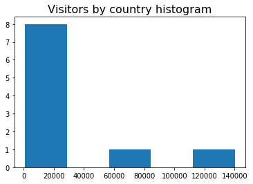

```python
cntr_visits = (df_new[["country", "VisitorURL"]].groupby(["country"], as_index=False).count())
cntr_visits = cntr_visits.rename({"VisitorURL": "total_visitors"}, axis=1)
cntr_visits.sort_values(['total_visitors'], inplace=True, ascending=False)
#cntr_visits.head()
plt.hist(cntr_visits.total_visitors[:10], bins=5)
plt.title('Visitors by country histogram', fontsize=titlesize)
plt.show()
```

### Request code by date

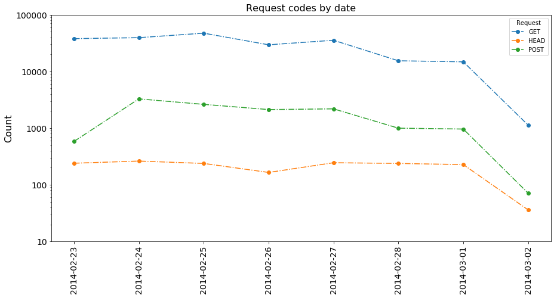

```python
fig, ax = plt.subplots(figsize=(15, 7))
reqdate = df_new.groupby(['Date', 'Request']).count()['VisitorURL'].unstack()
reqdate.plot(ax=ax, linestyle='-.', marker='o')
ax.set_yscale('log')
from matplotlib.ticker import ScalarFormatter
for axis in [ax.yaxis]:
    axis.set_major_formatter(ScalarFormatter())
ax.set_ylim([10, 100000])
ax.tick_params(axis='x', rotation=90, labelsize=ticksize)
ax.tick_params(axis='y', rotation=0, labelsize=ticksize)
ax.set_xlabel('')
ax.set_ylabel('Count', fontsize=titlesize)
ax.set_title('Request codes by date', fontsize=titlesize)
plt.show()
```

### Response code (Query status)

#### Distribution

```python
ranges = [0, 299, 399, 499, 599]
rescode_vis = (df_new[["ResponseCode",
                       "VisitorURL"]].groupby(pd.cut(df_new.ResponseCode, ranges), as_index=False).count())
rescode_vis = rescode_vis.rename({"VisitorURL": "total_visitors"}, axis=1)
rescode_vis['ResponseCode'] = ['2xx (Success)',
                               '3xx (Redirection)',
                               '4xx (Client Error)',
                               '5xx (Server Error)']
rescode_vis
```

|  | ResponseCode | total_visitors |
| --- | --- | --- |
| 0 | 2xx (Success) | 202563 |
| 1 | 3xx (Redirection) | 23939 |
| 2 | 4xx (Client Error) | 8478 |
| 3 | 5xx (Server Error) | 6 |

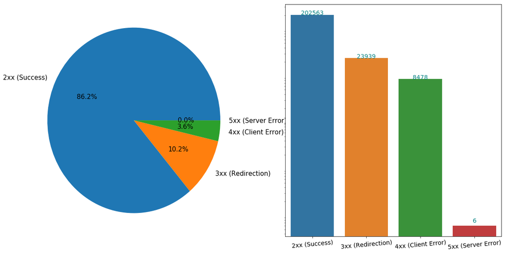

```python
f, ax = plt.subplots(1, 2, figsize=(20, 10))

by_status = rescode_vis.sort_values(by=['ResponseCode'], axis=0)
by_status = by_status.reset_index(drop=True)

by_status.total_visitors.plot.pie(autopct='%1.1f%%',
                                  fontsize=15,
                                  ax=ax[0],
                                  labels=by_status.ResponseCode)
ax[0].set_ylabel('')

ax[1] = sns.barplot(y='total_visitors',
                    x='ResponseCode',
                    data=rescode_vis,
                    orient='v')
ax[1].set_ylabel('')
ax[1].set_xlabel('')
ax[1].set_yscale('log')
ax[1].set_yticks([])
ax[1].tick_params(axis='both', labelsize=ticksize, rotation=5)
for index, data in enumerate(rescode_vis.total_visitors):
    plt.text(x=index,
             y=data + 1,
             s=f"{data}",
             color=colors,
             fontdict=dict(fontsize=ticksize),
             ha='center')
plt.show()
```

#### Response code by date

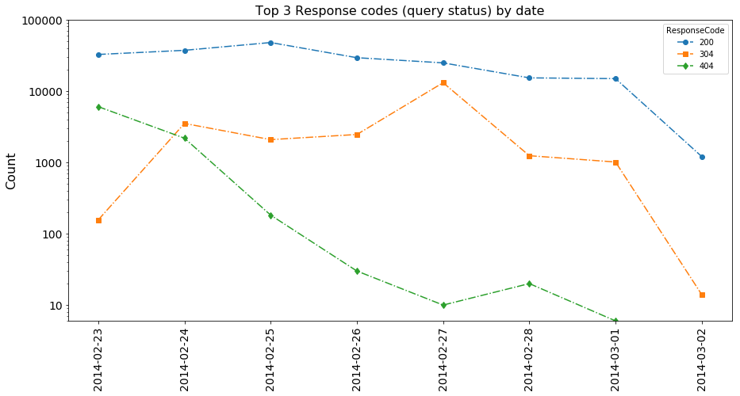

```python
fig, ax = plt.subplots(figsize=(15, 7))
resdate = df_new.groupby(['Date', 'ResponseCode']).count()['VisitorURL'].unstack()
resdate= resdate.T
d1=resdate[:][:1]
d2=resdate[:][4:5]
d3=resdate[:][8:9]
d1.T.plot(ax=ax, linestyle='-.', marker='o')
d2.T.plot(ax=ax, linestyle='-.', marker='s')
d3.T.plot(ax=ax, linestyle='-.', marker='d')
ax.set_yscale('log')
from matplotlib.ticker import ScalarFormatter
for axis in [ax.yaxis]:
    axis.set_major_formatter(ScalarFormatter())
ax.set_ylim([0, 100000])
ax.tick_params(axis='x', rotation=90, labelsize=ticksize)
ax.tick_params(axis='y', rotation=0, labelsize=ticksize)
ax.set_xlabel('')
ax.set_ylabel('Count', fontsize=titlesize)
ax.set_title('Top 3 Response codes (query status) by date', fontsize=titlesize)
plt.show()
```

### Visitors by country

```python
df = (df_new[["country", "VisitorURL"]].groupby(["country"], as_index=False).count())
df.sort_values(['VisitorURL'], inplace=True, ascending=False)
df2 = df[:5].copy()
new_row = pd.DataFrame(data={'country': ['others'],'VisitorURL': [df['VisitorURL'][5:].sum()]})
df2 = pd.concat([df2, new_row])
df2
```

|  | country | VisitorURL |
| --- | --- | --- |
| 50 | Spain | 140378 |
| 59 | United States | 68444 |
| 12 | China | 6852 |
| 35 | Netherlands | 6292 |
| 22 | Germany | 1858 |
| 0 | others | 10003 |

#### Top 5 countries

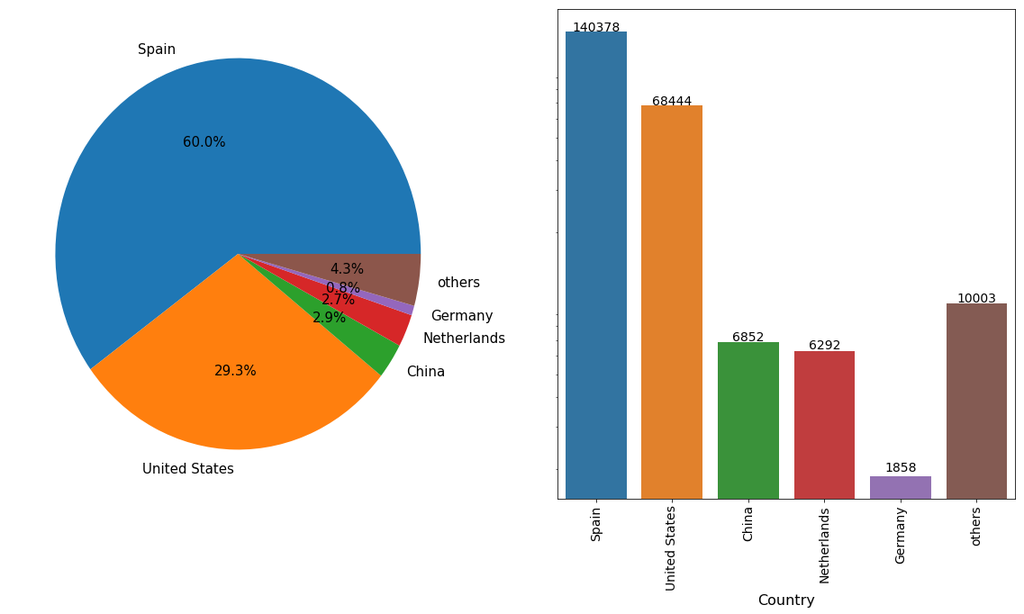

```python
f, ax = plt.subplots(1, 2, figsize=(20, 10))

df2.VisitorURL.plot.pie(autopct='%1.1f%%',
                                  fontsize=15,
                                  ax=ax[0],
                                  labels=df2.country)
ax[0].set_ylabel('')

ax[1] = sns.barplot(y='VisitorURL',
                    x='country',
                    data=df2,
                    orient='v')
ax[1].set_ylabel('')
ax[1].set_xlabel('Country', fontsize=titlesize)
ax[1].set_yscale('log')
ax[1].set_yticks([])
ax[1].tick_params(axis='both', labelsize=ticksize, rotation=90)
for index, data in enumerate(df2.VisitorURL):
    plt.text(x=index,
             y=data + 100,
             s=f"{data}",
             color='black',
             fontdict=dict(fontsize=ticksize),
             ha='center')
plt.show()
```

#### Countries by date

```python
datecntry = df_new.groupby(['Date', 'country']).count()['VisitorURL'].unstack()
datecntry.fillna(0, inplace = True)
#print(df.head())
top5_country = (datecntry.iloc[4:].sum().sort_values(ascending=False).head(5).index.values)
print(top5_country)
datecntry = datecntry[top5_country]
datecntry
```

```
['Spain' 'United States' 'Netherlands' 'China' 'Italy']
```

| country Date | Spain | United States | Netherlands | China | Italy |
| --- | --- | --- | --- | --- | --- |
| 2014-02-23 | 7429.0 | 25014.0 | 1085.0 | 3178.0 | 110.0 |
| 2014-02-24 | 28999.0 | 10045.0 | 333.0 | 2236.0 | 0.0 |
| 2014-02-25 | 31647.0 | 14643.0 | 1168.0 | 367.0 | 149.0 |
| 2014-02-26 | 20964.0 | 7145.0 | 1170.0 | 321.0 | 67.0 |
| 2014-02-27 | 29882.0 | 4538.0 | 954.0 | 322.0 | 378.0 |
| 2014-02-28 | 10389.0 | 3384.0 | 680.0 | 234.0 | 307.0 |
| 2014-03-01 | 10418.0 | 3417.0 | 902.0 | 178.0 | 1.0 |
| 2014-03-02 | 650.0 | 258.0 | 0.0 | 16.0 | 2.0 |

[figure not shown]

```python
fig = plt.figure(figsize=(12,5));
p1 = plt.plot(datecntry, '-.', marker='o')
plt.tick_params(axis='x', rotation=90, labelsize=ticksize)
plt.tick_params(axis='y', labelsize=ticksize)
plt.xlabel('', fontsize=xynamesize)
plt.ylabel('No. of visits', fontsize=xynamesize)
plt.title('Top 5 countries by date', fontsize=titlesize)
plt.legend(top5_country)
plt.grid('on')
```

### Browser distribution

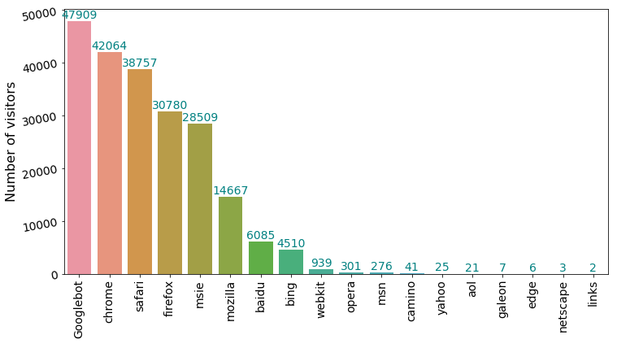

```python
df = (df_new[["Browser", "VisitorURL"]].groupby(["Browser"], as_index=False).count())
df.sort_values(['VisitorURL'], inplace=True, ascending=False)
#print(df.head())
fig = plt.figure(figsize=(12, 6))
plot_ = sns.barplot(y='VisitorURL', x='Browser', data=df, orient='v')

plt.tick_params(axis='x', rotation=90, labelsize=ticksize)
plt.tick_params(axis='y', rotation=10, labelsize=ticksize)
plt.xlabel('', fontsize=xynamesize)
plt.ylabel('Number of visitors', fontsize=xynamesize)
for index, data in enumerate(df.VisitorURL):
    plt.text(x=index,
             y=data + 500,
             s=f"{data}",
             color=colors,
             fontdict=dict(fontsize=ticksize),
             ha='center')
plt.show()
```

#### Top 5 browsers

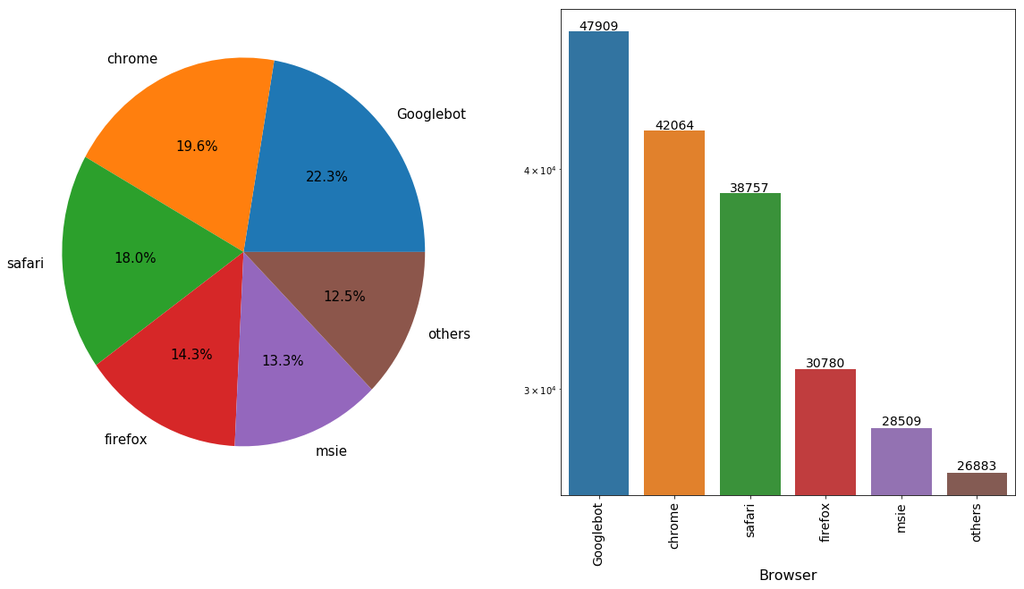

```python
df2 = df[:5].copy()
new_row = pd.DataFrame(data={'Browser': ['others'],'VisitorURL': [df['VisitorURL'][5:].sum()]})
df2 = pd.concat([df2, new_row])
#print(df2)

f, ax = plt.subplots(1, 2, figsize=(20, 10))
fig.suptitle('Delay statistics by months and days of week', fontsize=titlesize)

df2.VisitorURL.plot.pie(autopct='%1.1f%%',
                                  fontsize=15,
                                  ax=ax[0],
                                  labels=df2.Browser)
ax[0].set_ylabel('')

ax[1] = sns.barplot(y='VisitorURL',
                    x='Browser',
                    data=df2,
                    orient='v')
ax[1].set_ylabel('')
ax[1].set_xlabel('Browser', fontsize=titlesize)
ax[1].set_yscale('log')
ax[1].set_yticks([])
ax[1].tick_params(axis='both', labelsize=ticksize, rotation=90)
for index, data in enumerate(df2.VisitorURL):
    plt.text(x=index,
             y=data + 100,
             s=f"{data}",
             color='black',
             fontdict=dict(fontsize=ticksize),
             ha='center')
plt.show()
```

```python
top5_browser = df2.Browser
top5_browser
```

```
0     Googlebot
5        chrome
15       safari
7       firefox
11         msie
0        others
Name: Browser, dtype: object
```

#### Browsers by date

```python
df = df_new.groupby(['Date', 'Browser']).count()['VisitorURL'].unstack()
df.head()
```

| Browser Date | Googlebot | aol | baidu | bing | camino | chrome | edge | firefox | galeon | links | mozilla | msie | msn | netscape | opera | safari | webkit | yahoo |
| --- | --- | --- | --- | --- | --- | --- | --- | --- | --- | --- | --- | --- | --- | --- | --- | --- | --- | --- |
| 2014-02-23 | 18087.0 | 11.0 | 3047.0 | 1579.0 | 2.0 | 1818.0 | 2.0 | 882.0 | 1.0 | 1.0 | 6382.0 | 939.0 | 75.0 | NaN | 36.0 | 4511.0 | 110.0 | 2.0 |
| 2014-02-24 | 7330.0 | 2.0 | 1999.0 | 957.0 | 19.0 | 8329.0 | 2.0 | 5760.0 | NaN | 1.0 | 997.0 | 7144.0 | 101.0 | NaN | 201.0 | 6689.0 | 59.0 | 4.0 |
| 2014-02-25 | 12781.0 | NaN | 257.0 | 360.0 | 3.0 | 10594.0 | NaN | 4224.0 | 2.0 | NaN | 1656.0 | 5825.0 | 18.0 | NaN | 19.0 | 10518.0 | 143.0 | 7.0 |
| 2014-02-26 | 4545.0 | 3.0 | 225.0 | 621.0 | 3.0 | 7952.0 | NaN | 3930.0 | 1.0 | NaN | 1912.0 | 5596.0 | 22.0 | NaN | 16.0 | 4463.0 | 138.0 | 1.0 |
| 2014-02-27 | 2323.0 | 2.0 | 257.0 | 228.0 | 3.0 | 6480.0 | 1.0 | 13705.0 | 1.0 | NaN | 1318.0 | 4968.0 | 29.0 | 3.0 | 19.0 | 5732.0 | 301.0 | 1.0 |

```python
df2 = df[top5_browser[:5]]
df2
```

| Browser Date | Googlebot | chrome | safari | firefox | msie |
| --- | --- | --- | --- | --- | --- |
| 2014-02-23 | 18087.0 | 1818.0 | 4511.0 | 882.0 | 939.0 |
| 2014-02-24 | 7330.0 | 8329.0 | 6689.0 | 5760.0 | 7144.0 |
| 2014-02-25 | 12781.0 | 10594.0 | 10518.0 | 4224.0 | 5825.0 |
| 2014-02-26 | 4545.0 | 7952.0 | 4463.0 | 3930.0 | 5596.0 |
| 2014-02-27 | 2323.0 | 6480.0 | 5732.0 | 13705.0 | 4968.0 |
| 2014-02-28 | 1442.0 | 3269.0 | 3358.0 | 946.0 | 2850.0 |
| 2014-03-01 | 1401.0 | 3622.0 | 3486.0 | 1333.0 | 1187.0 |

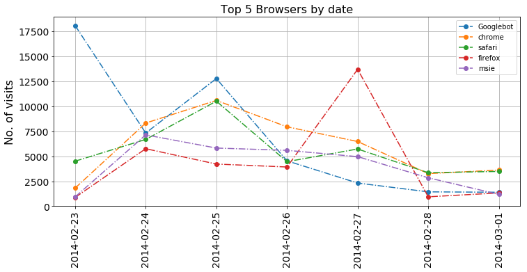

```python
fig = plt.figure(figsize=(12,5));
p1 = plt.plot(df2, '-.', marker='o')
plt.tick_params(axis='x', rotation=90, labelsize=ticksize)
plt.tick_params(axis='y', labelsize=ticksize)
plt.xlabel('', fontsize=xynamesize)
plt.ylabel('No. of visits', fontsize=xynamesize)
plt.title('Top 5 Browsers by date', fontsize=titlesize)
plt.legend(df2.columns)
plt.grid('on')
```

### Platform distribution

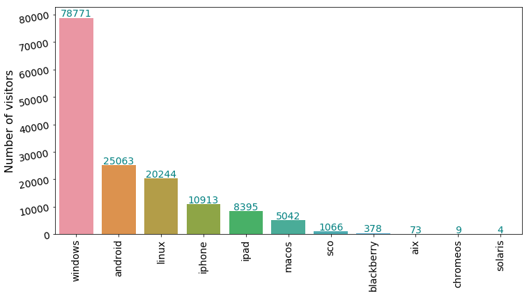

```python
df = (df_new[["Platform", "VisitorURL"]].groupby(["Platform"], as_index=False).count())
df.sort_values(['VisitorURL'], inplace=True, ascending=False)
#print(df.head())
fig = plt.figure(figsize=(12, 6))
plot_ = sns.barplot(y='VisitorURL', x='Platform', data=df, orient='v')

plt.tick_params(axis='x', rotation=90, labelsize=ticksize)
plt.tick_params(axis='y', rotation=10, labelsize=ticksize)
plt.xlabel('', fontsize=xynamesize)
plt.ylabel('Number of visitors', fontsize=xynamesize)
for index, data in enumerate(df.VisitorURL):
    plt.text(x=index,
             y=data + 500,
             s=f"{data}",
             color=colors,
             fontdict=dict(fontsize=ticksize),
             ha='center')
plt.show()
```

#### Top platforms

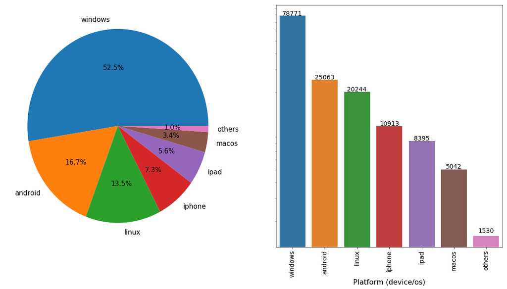

```python
df2 = df[:6].copy()
new_row = pd.DataFrame(data={'Platform': ['others'],'VisitorURL': [df['VisitorURL'][6:].sum()]})
df2 = pd.concat([df2, new_row])
#print(df2)

f, ax = plt.subplots(1, 2, figsize=(20, 10))

df2.VisitorURL.plot.pie(autopct='%1.1f%%',
                                  fontsize=15,
                                  ax=ax[0],
                                  labels=df2.Platform)
ax[0].set_ylabel('')

ax[1] = sns.barplot(y='VisitorURL',
                    x='Platform',
                    data=df2,
                    orient='v')
ax[1].set_ylabel('')
ax[1].set_xlabel('Platform (device/os)', fontsize=titlesize)
ax[1].set_yscale('log')
ax[1].set_yticks([])
ax[1].tick_params(axis='both', labelsize=ticksize, rotation=90)
for index, data in enumerate(df2.VisitorURL):
    plt.text(x=index,
             y=data + 100,
             s=f"{data}",
             color='black',
             fontdict=dict(fontsize=ticksize),
             ha='center')
plt.show()
```

#### Platforms by date

```python
top5_platform = df2.Platform
top5_platform
```

```
10    windows
1     android
6       linux
5      iphone
4        ipad
7       macos
0      others
Name: Platform, dtype: object
```

```python
df = df_new.groupby(['Date', 'Platform']).count()['VisitorURL'].unstack()
df.head()
```

| Platform Date | aix | android | blackberry | chromeos | ipad | iphone | linux | macos | sco | solaris | windows |
| --- | --- | --- | --- | --- | --- | --- | --- | --- | --- | --- | --- |
| 2014-02-23 | 26.0 | 2436.0 | 40.0 | 3.0 | 1400.0 | 1353.0 | 3737.0 | 403.0 | 288.0 | NaN | 3114.0 |
| 2014-02-24 | 5.0 | 5239.0 | 87.0 | 4.0 | 1184.0 | 2467.0 | 2447.0 | 954.0 | 193.0 | 1.0 | 16551.0 |
| 2014-02-25 | 21.0 | 6801.0 | 1.0 | 1.0 | 2266.0 | 2234.0 | 903.0 | 1123.0 | 252.0 | 1.0 | 18783.0 |
| 2014-02-26 | 9.0 | 3644.0 | NaN | NaN | 976.0 | 885.0 | 1286.0 | 907.0 | 141.0 | 1.0 | 14976.0 |
| 2014-02-27 | 9.0 | 2997.0 | 250.0 | NaN | 1386.0 | 1666.0 | 10608.0 | 553.0 | 90.0 | 0.0 | 14192.0 |

```python
df2 = df[top5_platform[:5]]
df2
```

| Platform Date | windows | android | linux | iphone | ipad |
| --- | --- | --- | --- | --- | --- |
| 2014-02-23 | 3114.0 | 2436.0 | 3737.0 | 1353.0 | 1400.0 |
| 2014-02-24 | 16551.0 | 5239.0 | 2447.0 | 2467.0 | 1184.0 |
| 2014-02-25 | 18783.0 | 6801.0 | 903.0 | 2234.0 | 2266.0 |
| 2014-02-26 | 14976.0 | 3644.0 | 1286.0 | 885.0 | 976.0 |
| 2014-02-27 | 14192.0 | 2997.0 | 10608.0 | 1666.0 | 1386.0 |
| 2014-02-28 | 6170.0 | 2084.0 | 852.0 | 737.0 | 543.0 |
| 2014-03-01 | 4985.0 | 1862.0 | 411.0 | 1571.0 | 640.0 |

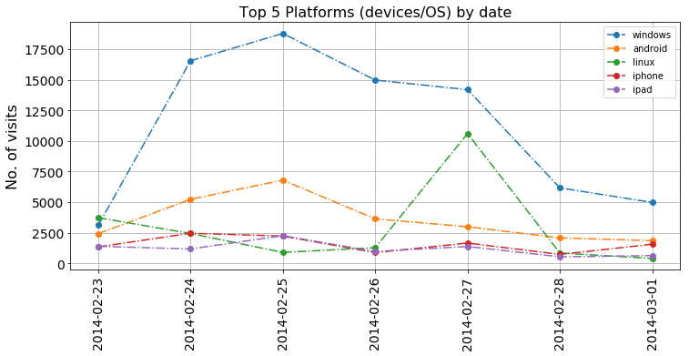

```python
fig = plt.figure(figsize=(12,5));
p1 = plt.plot(df2, '-.', marker='o')
plt.tick_params(axis='x', rotation=90, labelsize=ticksize)
plt.tick_params(axis='y', labelsize=ticksize)
plt.xlabel('', fontsize=xynamesize)
plt.ylabel('No. of visits', fontsize=xynamesize)
plt.title('Top 5 Platforms (devices/OS) by date', fontsize=titlesize)
plt.legend(df2.columns)
plt.grid('on')
```